# Intro to lehdr: Grabbing Longitudinal and Employer-Household Dynamics (LEHD) data!

### Integrate the LODES data with `sf` objects for visualization

Note: The authors mentioned in their package release documents that their next steps are the integration of the package with the `sf` and `tigris` packages to allow for easier mapping of LODES data.

```r
# get counties and their geometries from 2021 Census data
PA_county_2021 <- get_acs(geography = "county",
                          state= 42, #PA
                          year = 2021,
                          variables = c('B08006_001'),
                          survey = "acs5",
                          output = "wide",
                          geometry = TRUE)

totjobs_PA_county_2021_sf <- merge(x=PA_county_2021, y=totjobs_PA_county_2021,
                                by.x="GEOID", by.y="w_county", all.x=TRUE)
```

Let’s first visualize how many primary jobs are located in each county in Pennsylvania.

```r
#Map total primary jobs in Pennsylvania couties
pal <- leaflet::colorNumeric(viridis::viridis_pal(option = "F", direction = 1,
                                                  begin = 1, end = 0)(5),
                             domain = totjobs_PA_county_2021$totjobs)

totjobs_PA_county_2021_sf %>%
  mutate(label = paste0("<b>", NAME, ":</b> ", round(totjobs))) %>%
  leaflet(.) %>%
  addProviderTiles(providers$CartoDB.Positron) %>%
  addPolygons(
    color = "transparent", weight = 0.1, opacity = 1,
    fillColor = ~pal(totjobs), fillOpacity = 0.7,
    label = ~lapply(label, HTML),
    labelOptions = labelOptions(direction = "top"),
    highlight = highlightOptions(
      color = "#FFF", bringToFront = TRUE
    )
  ) %>%
  addLegend(
    values = ~totjobs, opacity = 0.7,
    pal = pal,
    title = "Total primary jobs",
    position = "topleft"
  )
```

[interactive chart not shown]

### Visualize job flows using the LODES OD data

Another question that we can answer using the LODES OD data is people’s commuting pattern. For example, we can use the OD data retrieved above to plot workforce flows from all counties in Pennsylvania to Philadelphia County (geoid = ‘42101’). In this example, to keep the map readable, we only plot the counties of 2k or more people whose workplace is in Philadelphia County.

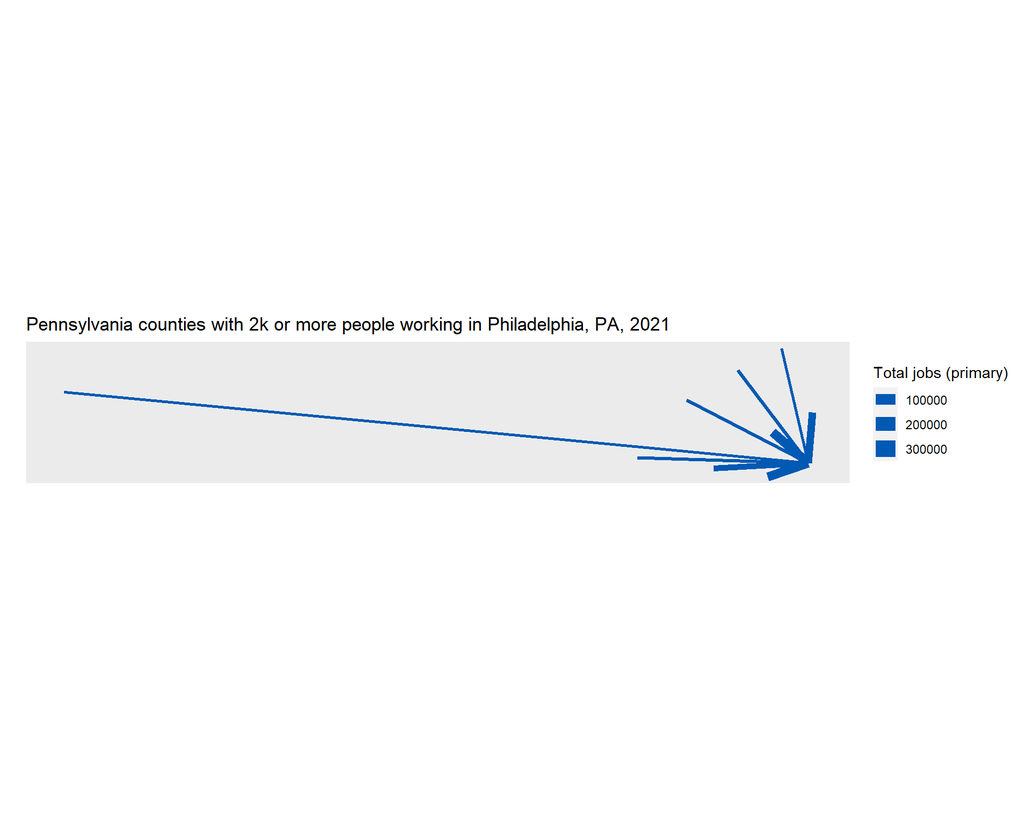

```r
# generate centroids of Philadelphia counties
centroids_PA_county_2021<- st_centroid(PA_county_2021) %>%
  st_transform(st_crs(PA_county_2021)) %>%
  mutate(lon = map_dbl(geometry, ~st_centroid(.x)[[2]]),
         lat = map_dbl(geometry, ~st_centroid(.x)[[1]]))


# join x y coordinates to the origin and then the destination points.
or_PA_county_2021 <- merge(od_PA_county_2021, centroids_PA_county_2021, by.x="h_county", by.y="GEOID") %>%
  rename(or_lon = "lon",
         or_lat = "lat")
dest_PA_county_2021 <-  merge(or_PA_county_2021, centroids_PA_county_2021, by.x="w_county", by.y="GEOID")%>%
  rename(dest_lon = "lon",
         dest_lat = "lat")

options(scipen = 999)

# plot
# reference: https://jcheshire.com/visualisation/mapping-flows/
ggplot(
  dest_PA_county_2021[which(dest_PA_county_2021$w_county == "42101" & dest_PA_county_2021$S000 >= 2000),],
       aes(oX, oY))+
  #plot line segments.
  geom_segment(aes(x=or_lat, y=or_lon, xend=dest_lat, yend=dest_lon, #alpha=S000,
                   size = S000),
               col="#0059b3")+
  #scale_alpha_continuous(range = c(0.03, 0.3))+
  #geom_polygon(data = totjobs_PA_county_2021_sf, fill="#e1e1e1", colour = "grey20") +
  scale_x_continuous("", breaks=NULL) +
  scale_y_continuous("", breaks=NULL) +
  labs(size = "Total jobs (primary)",
       title = "Pennsylvania counties with 2k or more people working in Philadelphia, PA, 2021") +
  coord_equal()
```

**This map can be visually improved with your efforts! Use the code above as starting point and build on it!**

### Retrieve multiple states or years to see trends

`lehdr` can also be used to retrieve multiple states and years at the same time by creating a vector or list for the `state` and/or `year` parameter. For instance, we want to compare the trends in the share of low-income jobs (jobs with earnings $1250 per month or less) from 2015 to 2019 in Pennsylvania and Ohio. We can use parameters to confine the grabbing: `year = 2015:2019`, `state = c('pa', 'oh')`, `agg_geo = "state"`.

Note: Not all years are available for each state. To see all options for lodes_type, job_type, and segment and the availability for each state/year, please see the most recent LEHD Technical Document at https://lehd.ces.census.gov/data/lodes/LODES7/.

In the following table, `C000` and `CE01` are # total jobs and # low-income jobs. To get the share of low-income jobs over all (primary) jobs, we will calculate the ratio of `C000` and `CE01`.

```r
# download and load 2015-21 wac data for Pennsylvania and New York states and aggregate
# to the state level, downloading only primary jobs
wac_PA_OH_2015_2021 <- grab_lodes(
                                state= c('pa', 'oh'),
                                year=2015:2019,
                                lodes_type = "wac",
                                job_type = "JT01",
                                agg_geo = "state",
                               )
# calculate thes share of low-income jobs
wac_PA_OH_2015_2021 <- wac_PA_OH_2015_2021 %>%
  mutate(pct_lowinc = CE01/C000 * 100)


# show the wac data for PA and OH
wac_PA_OH_2015_2021 %>%
  arrange(desc(state)) %>%
  select(year, state, C000, CE01, pct_lowinc) %>%
  rename("Year" = year,
         "State" = state,
         "Total jobs" = C000,
         "Low-income jobs" = CE01,
         "Share of low-income job"= pct_lowinc) %>%
  kable(., "html", digits=1, align = "lccrr", format.args = list(big.mark = ","),
        caption = "Total jobs and low-income jobs in Pennsylvania and Ohio, 2015-19, from Workplace Area Characteristics tables (aggregated)") %>%
  kable_styling() %>%
  scroll_box(width = "800px", height = "600px")
```

Total jobs and low-income jobs in Pennsylvania and Ohio, 2015-19, from Workplace Area Characteristics tables (aggregated)

| Year | State | Total jobs | Low-income jobs | Share of low-income job |
| --- | --- | --- | --- | --- |
| 2015 | PA | 5,271,351 | 1,043,846 | 19.8 |
| 2016 | PA | 5,333,371 | 1,028,590 | 19.3 |
| 2017 | PA | 5,372,721 | 1,007,596 | 18.8 |
| 2018 | PA | 5,428,524 | 982,295 | 18.1 |
| 2019 | PA | 5,436,455 | 956,291 | 17.6 |
| 2015 | OH | 4,843,268 | 1,010,419 | 20.9 |
| 2016 | OH | 4,913,612 | 998,398 | 20.3 |
| 2017 | OH | 4,949,710 | 981,207 | 19.8 |
| 2018 | OH | 4,978,965 | 950,755 | 19.1 |
| 2019 | OH | 5,010,746 | 926,842 | 18.5 |

To better visualize the temporal trends and compare two states, we can plot a line graph using the retrieved wac data.

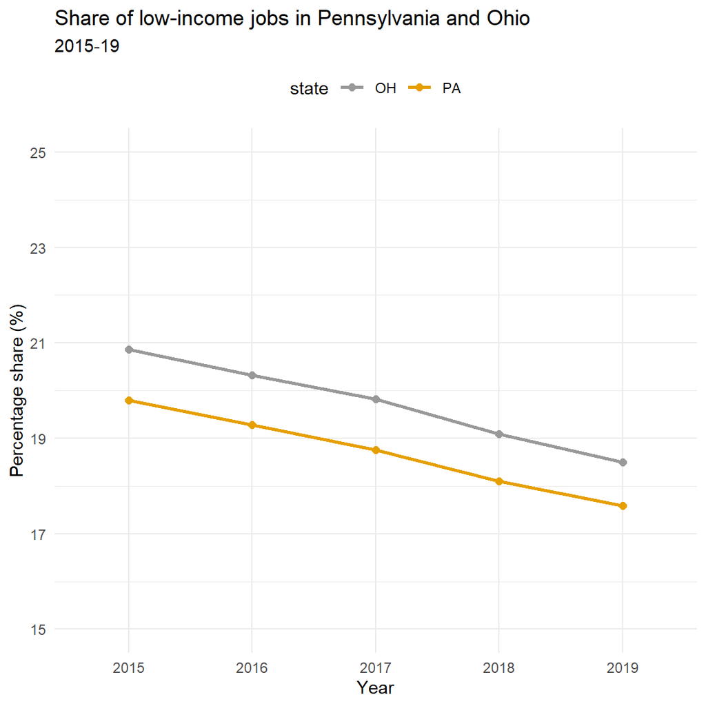

```r
# plot
ggplot(wac_PA_OH_2015_2021, aes(x = year, y=pct_lowinc, group=state)) +
  geom_line(size = 1, aes(color=state)) +
  geom_point(size = 2, aes(color=state)) +
  scale_color_manual(values=c("#999999", "#E69F00", "#56B4E9")) +
  scale_y_continuous(breaks = seq(15, 25, 2), limit = c(15, 25)) +
  labs(y = "Percentage share (%)", x = "Year",
       title = "Share of low-income jobs in Pennsylvania and Ohio",
       subtitle = "2015-19") +
  theme_minimal() +
  theme(legend.position="top")
```

## Conclusion

In this tutorial, we explored the fundamental usage of `lehdr` package to query LODES data from the LEHD FTP program and demonstrated some common tasks we can use the LODES data to accomplish:

- Basic: Use `grab_lodes()` to grab LODES origin-destination tables
- Integrate the LODES data with `sf` objects for visualization
- Visualize job flows using the LODES OD data
- Retrieve multiple states or years to see trends

Please be to tuned for more new functions in the `ledhr` package! Additional resources for using the package can be found in the [package webpage](https://jamgreen.github.io/lehdr/articles/getting_started.html) and the [user manual](https://cran.utstat.utoronto.ca/web/packages/lehdr/lehdr.pdf).

[^1]: GitHub repoitory of lehdr: https://github.com/jamgreen/lehdr
[^2]: I failed to run this function.
[^3]: lehdr PDF Manual: https://cran.utstat.utoronto.ca/web/packages/lehdr/lehdr.pdf
[^4]: LODES Public Data Structure: https://lehd.ces.census.gov/data/lodes/LODES7/LODESTechDoc7.5.pdf